# Reproducible Research: Peer Assessment 1

Jan Kruijdenberg

7 mei 2017

## Introduction

It is now possible to collect a large amount of data about personal movement using activity monitoring devices such as a Fitbit, Nike Fuelband, or Jawbone Up. These type of devices are part of the “quantified self” movement – a group of enthusiasts who take measurements about themselves regularly to improve their health, to find patterns in their behavior, or because they are tech geeks. But these data remain under-utilized both because the raw data are hard to obtain and there is a lack of statistical methods and software for processing and interpreting the data.

This assignment makes use of data from a personal activity monitoring device. This device collects data at 5 minute intervals through out the day. The data consists of two months of data from an anonymous individual collected during the months of October and November, 2012 and include the number of steps taken in 5 minute intervals each day.

The data for this assignment can be downloaded from the course web site:

```
Dataset: Activity monitoring data [52K]
```

The variables included in this dataset are:

```
steps: Number of steps taking in a 5-minute interval (missing values are coded as NA)
date: The date on which the measurement was taken in YYYY-MM-DD format
interval: Identifier for the 5-minute interval in which measurement was taken
```

The dataset is stored in a comma-separated-value (CSV) file and there are a total of 17,568 observations in this dataset.

## Loading and preprocessing the data

```r
  # Loading Libraries
    library("ggplot2")
    library("lubridate")
# Obtain data and store it in variable ActMonDat
    url <-  "https://d396qusza40orc.cloudfront.net/repdata%2Fdata%2Factivity.zip"
    ActMonDat <-  read.table(unz("activity.zip", "activity.csv"),header = T,  sep = ","
                             ,colClasses = c("integer", "Date","integer"))
```

## What is mean total number of steps taken per day?

Missing values are ignored.

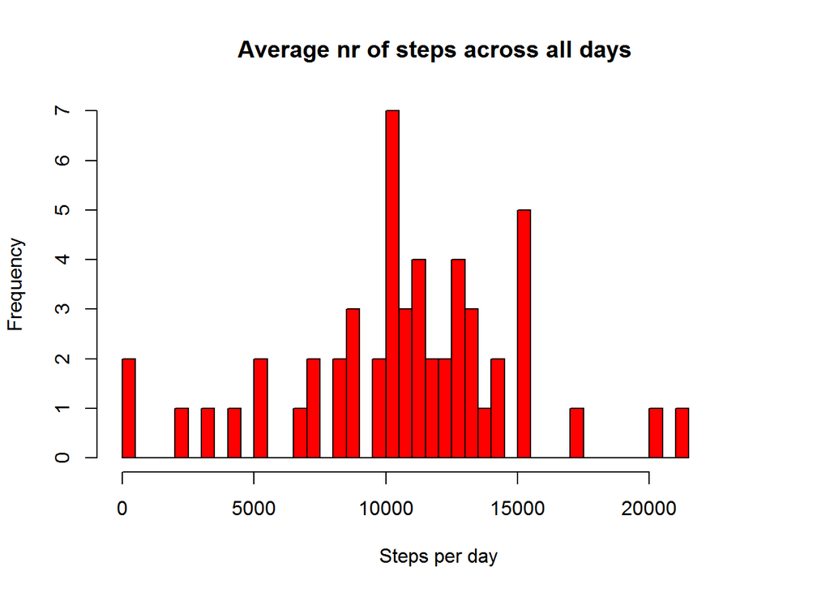

```r
  # Calculate total seps taken per day
    StepsDay <-  aggregate(steps ~ date, ActMonDat,  sum)


  # Create Histogram
    hist(StepsDay$steps,col="red"
        ,breaks=50
        ,main = "Average nr of steps across all days "
        ,xlab="Steps per day",xlim=c(0,24000)
        )
```

```r
    MeanNumberOfSteps<-(mean(StepsDay$steps))
```

The Mean number of steps is **10766.19**

```r
    MedianNumberOfSteps<-(median(StepsDay$steps))
```

The Median number of steps is **10765**

## What is the average daily activity pattern?

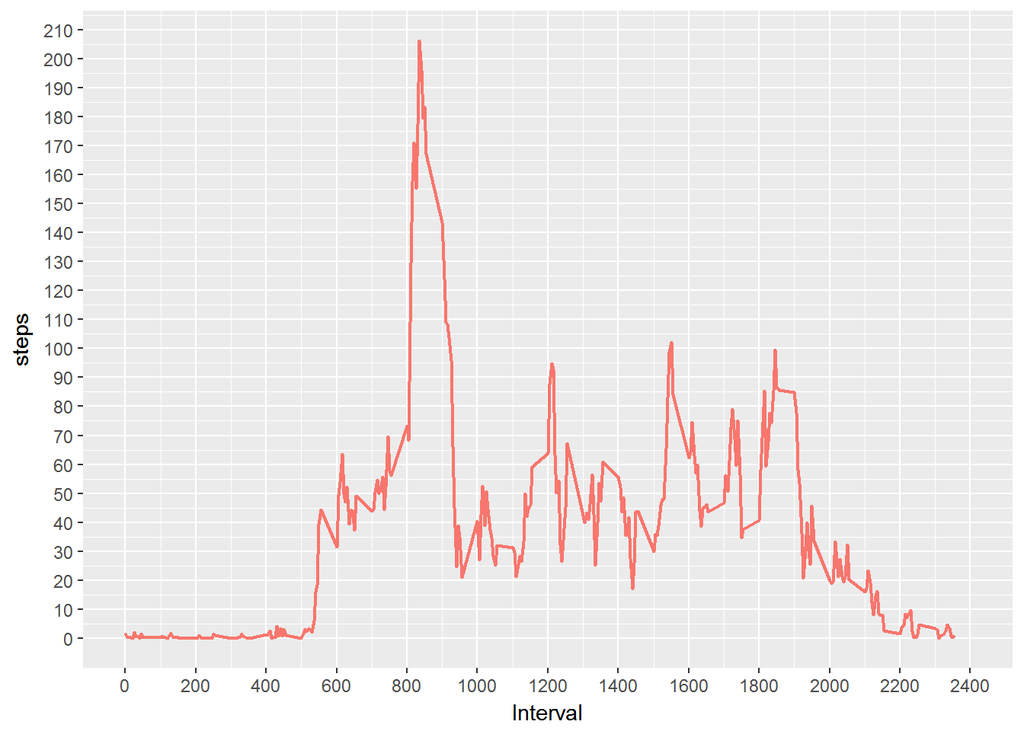

```r
 #time series plot
  avgSteps<- aggregate(x = list(steps = ActMonDat$steps), by = list(interval = ActMonDat$interval),
                             FUN = mean, na.rm = TRUE)

  ggplot(avgSteps,aes(x=interval,y=steps))+
    scale_x_continuous(name="Interval", breaks=seq(0, 2400, 200)
                       ,minor_breaks =seq(0, 2400, 100),limits=c(0,2400))+
    scale_y_continuous(name="steps",breaks=seq(0, 220, 10)
                       ,minor_breaks =seq(0, 220, 5) )+
    geom_line(aes(colour="red"),size=0.8,na.rm=TRUE)+
    theme(legend.position="none")
```

Maximum number of steps is on the following interval:

```r
MaxstepsInterval<-avgSteps[which.max(avgSteps$steps),"interval"]
MaxstepsAmount<-avgSteps[which.max(avgSteps$steps),"steps"]
```

The maximum number of steps (i.e. 206.17 ) is on interval **835**

## Imputing missing values

Total number of missing values in the dataset (i.e. the total number of rows with NAs)

```r
    MissingNum<-length(which(is.na(ActMonDat$steps)))
```

In total there are **2304** observations with missing values.

```r
  # Determine Average nr of steps per interval
    avgSteps<-mean(ActMonDat$steps,na.rm=TRUE)

  # Create ActMonDat2 by first copy ActMonDat and then replace NA values by the Average amount of steps
    ActMonDat2<-ActMonDat

    x<-1
    while (x<=nrow(ActMonDat))
    {
      Steps<-ActMonDat[x,"steps"]
      ActMonDat2[x,"steps"]<-ifelse(is.na(Steps),avgSteps,Steps)
      x<-x+1
    }
```

Make a histogram of the total number of steps taken each day and Calculate and report the mean and median total number of steps taken per day. Do these values differ from the estimates from the first part of the assignment? What is the impact of imputing missing data on the estimates of the total daily number of steps?

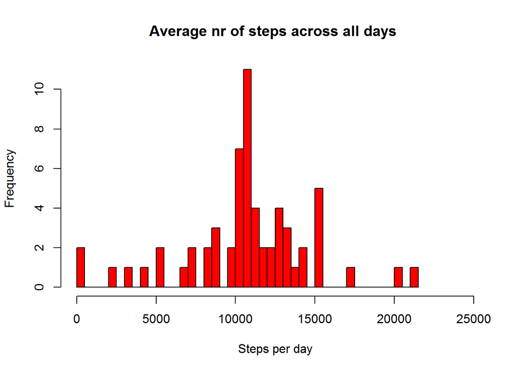

```r
  # Calculate total steps taken per day
    StepsDay2 <-  aggregate(steps ~ date, ActMonDat2,  sum)

  # Create Histogram
    hist(StepsDay2$steps,col="red"
        ,breaks=50
        ,main = "Average nr of steps across all days "
        ,xlab="Steps per day",xlim=c(0,25000)
        )
```

Mean number of steps

```r
    MeanNumberOfSteps2<-mean(StepsDay2$steps)
```

The Mean number of steps is **10766.19**

Median Number of steps

```r
    MedianNumberOfSteps2<-median(StepsDay2$steps)
```

The Median number of steps is **10766.19**

The impact of imputing missing data on the estimates of the total daily number of steps is that the mean remains the same while the median changes from **10765** to **10766.19** and becomes equal to the Mean.

## Are there differences in activity patterns between weekdays and weekends?

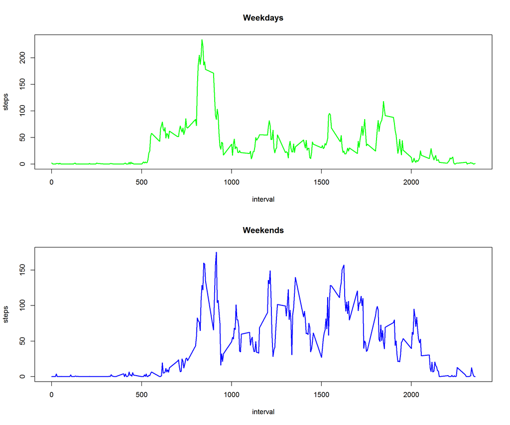

```r
# Create factor indicatin Weekend or Weekday
      ActMonDat$WeekDay<-ifelse(wday(ActMonDat$date) %in% c(7,1)==TRUE,"Weekend" ,"Weekday")

      # Summary of mean steps for weekends
      avgStepsWeekEnd<-with(ActMonDat[ActMonDat[,"WeekDay"]=="Weekend",]
           ,aggregate(x = list(steps = steps)
                      , by = list(interval = interval)
                      , FUN = mean, na.rm = TRUE))

      # Summary of mean steps for weekdays
      avgStepsWeekday<-with(ActMonDat[ActMonDat[,"WeekDay"]=="Weekday",]
                            ,aggregate(x = list(steps = steps)
                                       , by = list(interval = interval)
                                       , FUN = mean, na.rm = TRUE))



      par(mfrow = c(2, 1))

plot(avgStepsWeekday, type = "l", col = "green", main = "Weekdays",lwd=2)
plot(avgStepsWeekEnd, type = "l", col = "blue", main = "Weekends",lwd=2)
```

```r
par(mfrow = c(1, 1))
```

The comparison of both graps shows that there are differences in Weekday activities and Weenend activities.